# Тест #5

## Вариант #4

**Журавский Максим, группа 520**

```r
library("TSA")
library("tidyverse")
library(tseries)
library("lmtest")
```

### Исследование исходного временного ряда

Считаем файл с данными и отсортируем данные от старых к новым. Перейдем к дифференцированному ряду.

```r
df %>% head()
```

```
## # A tibble: 6 x 3
##   Date       Amount    Inc
##   <date>      <dbl>  <dbl>
## 1 2015-06-10  0.865 -2.91
## 2 2015-06-17  0.114 -0.751
## 3 2015-06-24  1.84   1.72
## 4 2015-07-01  0.392 -1.44
## 5 2015-07-08  1.64   1.25
## 6 2015-07-15  3.82   2.18
```

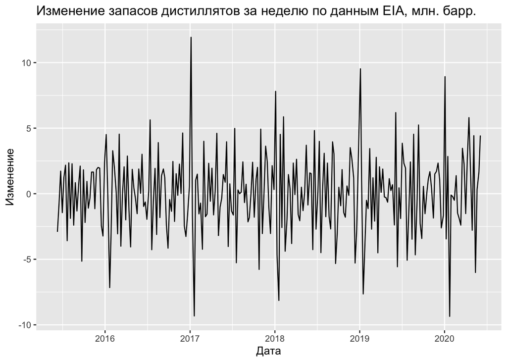

Исследуем ряд на стационарность с помощью критерия Дики-Фуллера с максимальным лагом, равным 60 неделям. Здесь и далее для проверки гипотез будем использовать уровень значимости $\alpha = 0.05$.

```r
adf.test(df$Inc, k=60, alternative = c("stationary"))
```

```
##
##  Augmented Dickey-Fuller Test
##
## data:  df$Inc
## Dickey-Fuller = -1.564, Lag order = 60, p-value = 0.7595
## alternative hypothesis: stationary
```

Т.к. значение p-value больше выбранного уровня значимости $\alpha$, мы не можем отвергать гипотезу о нестационарности временного ряда. Нестационарность также наблюдается и на графике: изменение запасов в начале года явно больше, чем к концу года.

Возьмем сезонную разность $y_t = y_t - y_{t - 52}$

```r
diff <- df %>%
  mutate(Diff = Inc - lag(Inc, n = 52)) %>%
  filter(!is.na(Diff))
```

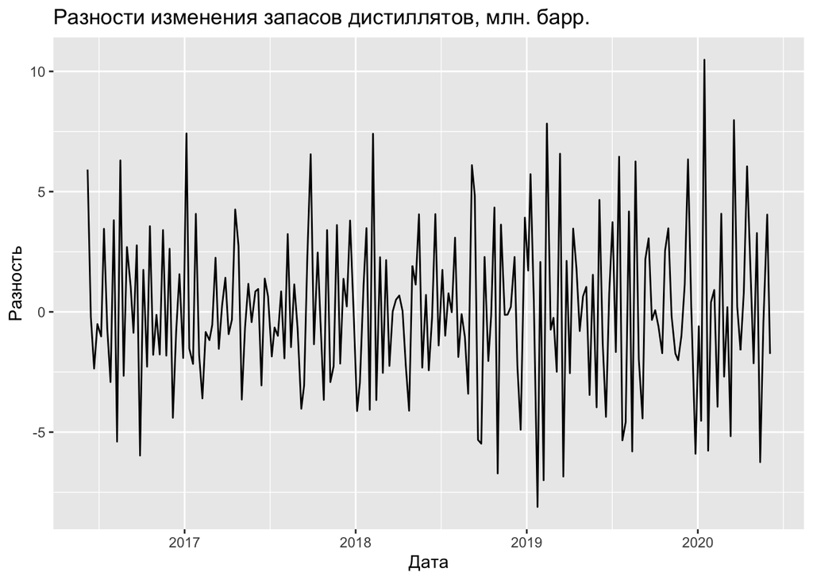

### Построение ARMA модели

Исследуем ACF и PACF для исследуемого временного ряда.

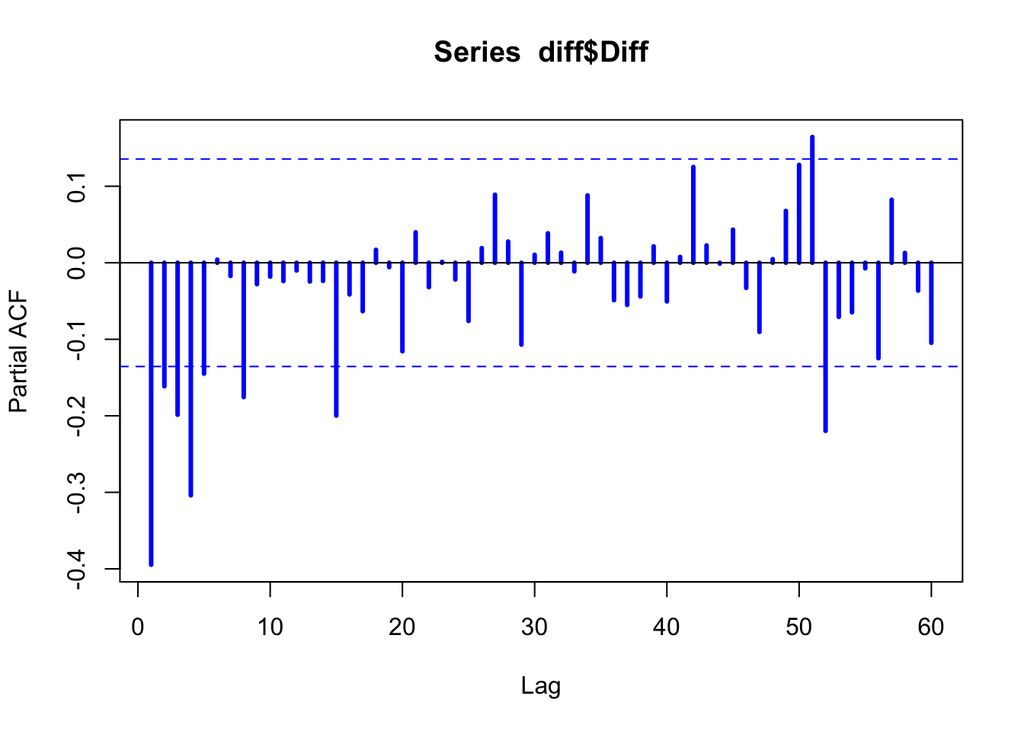

```r
pacf(diff$Diff, lwd = 3,lag.max = 60, col = "blue")
```

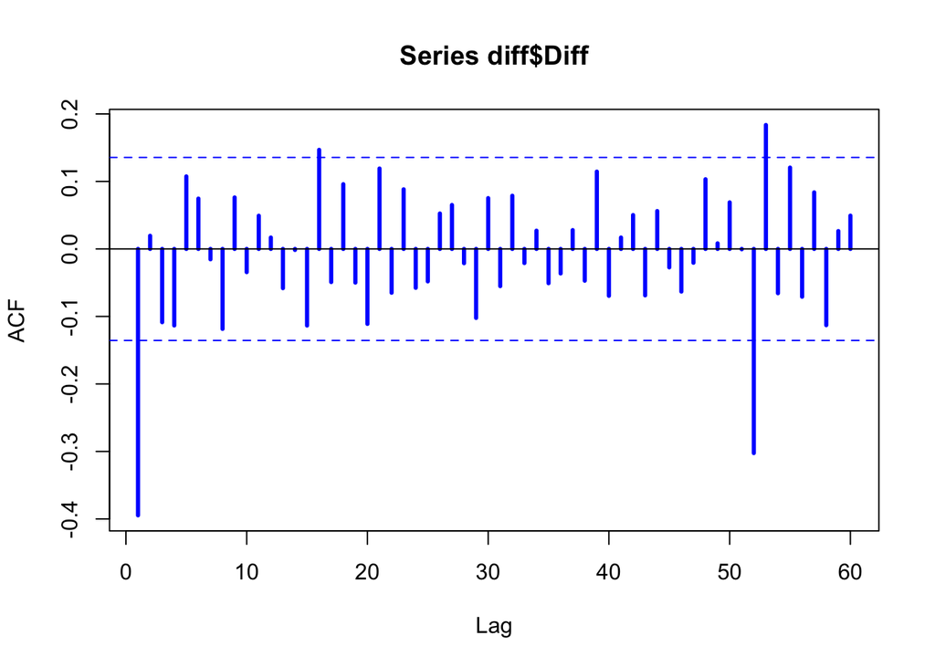

```r
acf(diff$Diff, lwd = 3,lag.max = 60, col = "blue")
```

Очевидно, период сезонности равен 52. Исходя из вида ACF, в качестве первой модели рассмотрим модель с сезонным скользящим средним 1 порядка и несезонным скользящим средним порядка 1.

```r
ma_model <- arima(diff$Diff, order = c(0,0,1), seasonal = list(order=c(0,0,1), period=52),method = "ML")
coeftest(ma_model)
```

```
##
## z test of coefficients:
##
##            Estimate Std. Error  z value  Pr(>|z|)
## ma1       -0.740473   0.068917 -10.7444 < 2.2e-16 ***
## sma1      -0.674329   0.131183  -5.1404 2.742e-07 ***
## intercept  0.028631   0.026899   1.0644    0.2871
## ---
## Signif. codes:  0 '***' 0.001 '**' 0.01 '*' 0.05 '.' 0.1 ' ' 1
```

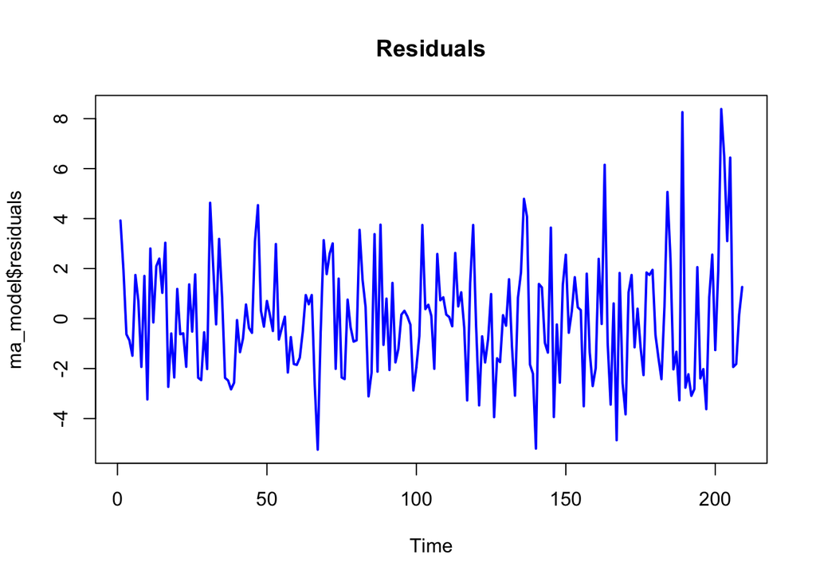

```r
plot(ma_model$residuals ,type = "l", col = "blue",lwd = 2,main = "Residuals")
```

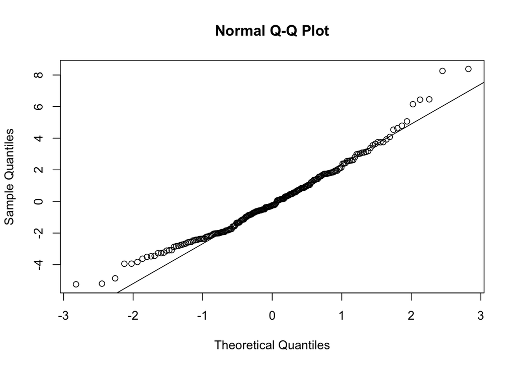

```r
qqnorm(ma_model$residuals)
qqline(ma_model$residuals)
```

```r
shapiro.test(ma_model$residuals)
```

```
##
##  Shapiro-Wilk normality test
##
## data:  ma_model$residuals
## W = 0.97525, p-value = 0.0009658
```

Согласно QQ-графику распредление остатков имеет более тяжелые хвосты, чем нормальное распределение. Ненормальность распределения подтверджает и результат теста Шапиро: гипотеза о нормальности остатков отвергается.

```r
Box.test(ma_model$residuals, lag = 52, type = "Ljung-Box", fitdf = 2)
```

```
##
##  Box-Ljung test
##
## data:  ma_model$residuals
## X-squared = 56.755, df = 50, p-value = 0.2378
```

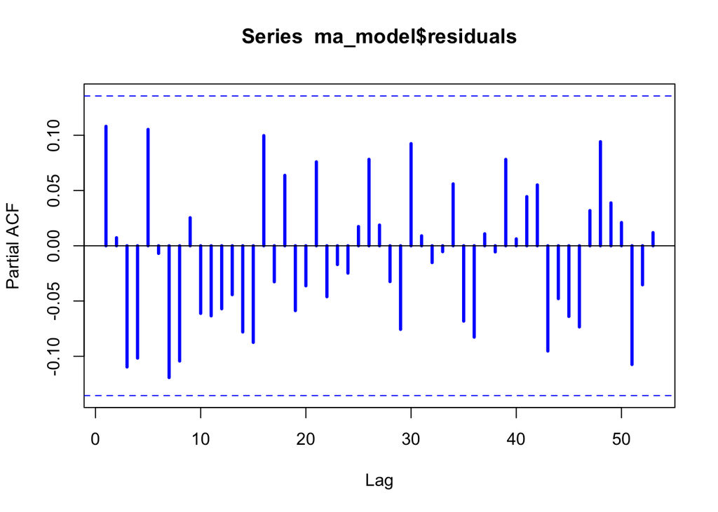

```r
pacf(ma_model$residuals, lwd = 3, lag.max = 53, col = "blue")
```

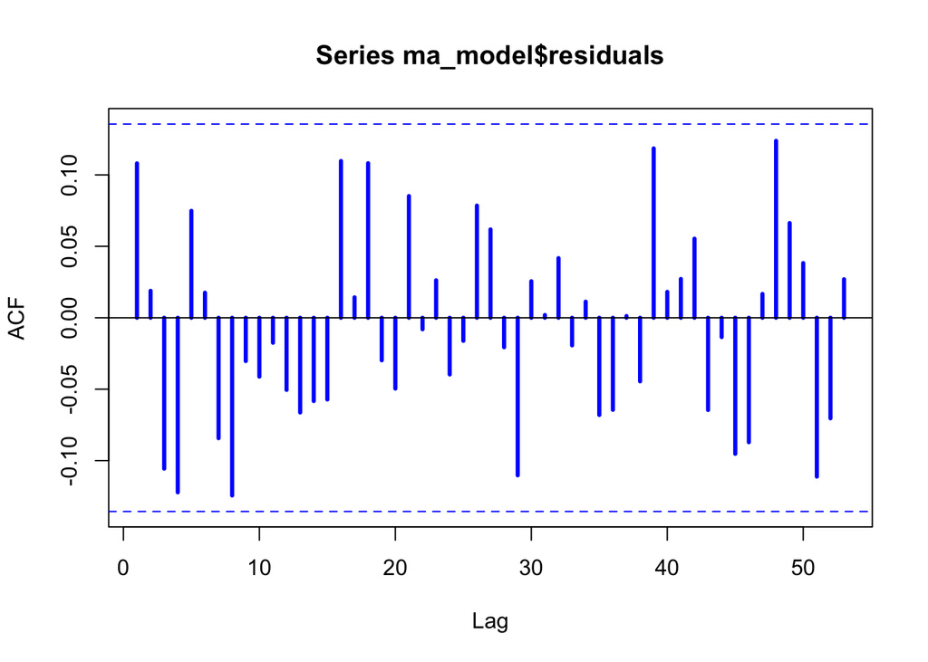

```r
acf(ma_model$residuals, lwd = 3, lag.max = 53, col = "blue")
```

Согласно тесту Бокса-Льюнга гипотеза о некоррелированности остатков не отвергается. На графиках коррелированность также не видна.

В качестве второй модели, основываясь на виде PACF, рассмотрим модель с сезонной авторегрессией первого порядка и несезонной авторегрессией 5 порядка.

```r
ar_model <- arima(diff$Diff, order = c(5,0,0), seasonal = list(order=c(1,0,0), period=52),method = "ML")
coeftest(ar_model)
```

```
##
## z test of coefficients:
##
##            Estimate Std. Error z value  Pr(>|z|)
## ar1       -0.632841   0.069355 -9.1246 < 2.2e-16 ***
## ar2       -0.400137   0.077817 -5.1420 2.718e-07 ***
## ar3       -0.393126   0.077892 -5.0471 4.487e-07 ***
## ar4       -0.381469   0.078780 -4.8422 1.284e-06 ***
## ar5       -0.096761   0.070594 -1.3707    0.1705
## sar1      -0.452979   0.068803 -6.5837 4.588e-11 ***
## intercept  0.030674   0.044545  0.6886    0.4911
## ---
## Signif. codes:  0 '***' 0.001 '**' 0.01 '*' 0.05 '.' 0.1 ' ' 1
```

Заметим, что для установленного уровня значимости коэффициент при слагаемом с несезонной задержкой 5 близок к нулю. Поэтому понизим порядок несезонной авторегрессии до 4.

```r
ar_model <- arima(diff$Diff, order = c(4,0,0), seasonal = list(order=c(1,0,0), period=52),method = "ML")
coeftest(ar_model)
```

```
##
## z test of coefficients:
##
##            Estimate Std. Error z value  Pr(>|z|)
## ar1       -0.603625   0.066291 -9.1057 < 2.2e-16 ***
## ar2       -0.367149   0.074352 -4.9380 7.894e-07 ***
## ar3       -0.359214   0.074230 -4.8392 1.304e-06 ***
## ar4       -0.323651   0.066924 -4.8361 1.324e-06 ***
## sar1      -0.461951   0.067413 -6.8526 7.253e-12 ***
## intercept  0.030113   0.048617  0.6194    0.5357
## ---
## Signif. codes:  0 '***' 0.001 '**' 0.01 '*' 0.05 '.' 0.1 ' ' 1
```

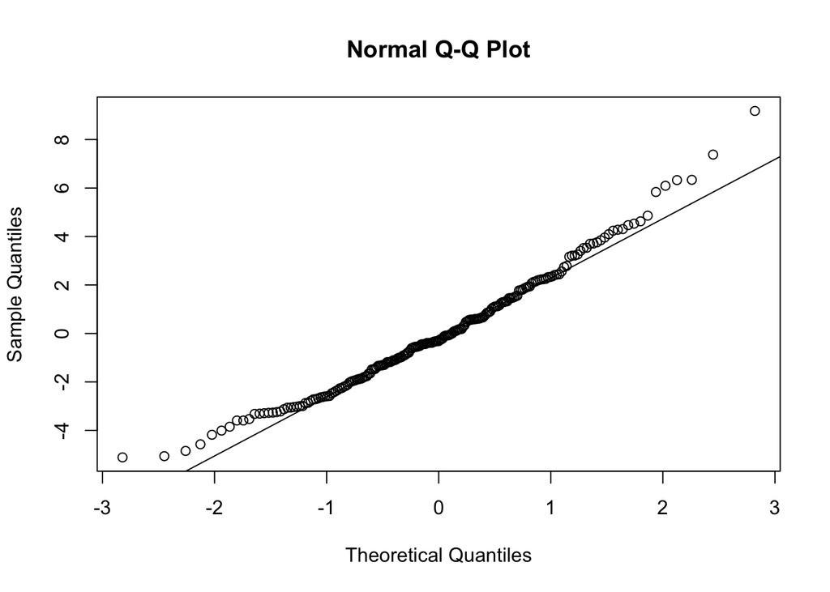

```r
qqnorm(ar_model$residuals)
qqline(ar_model$residuals)
```

```r
shapiro.test(ar_model$residuals)
```

```
##
##  Shapiro-Wilk normality test
##
## data:  ar_model$residuals
## W = 0.97878, p-value = 0.003021
```

Как и для первой модели, согласно результатам теста Шапиро гипотеза о нормальности остатков отвергается.

```r
Box.test(ar_model$residuals, lag = 52, type = "Ljung-Box", fitdf = 2)
```

```
##
##  Box-Ljung test
##
## data:  ar_model$residuals
## X-squared = 47.545, df = 50, p-value = 0.5724
```

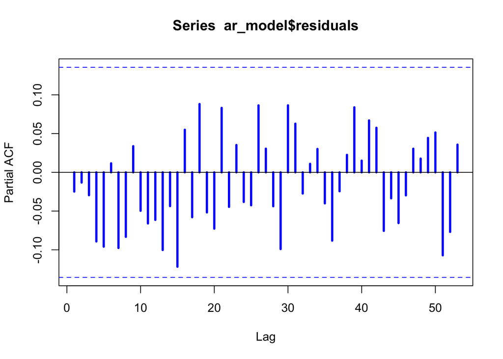

```r
pacf(ar_model$residuals, lwd = 3, lag.max = 53, col = "blue")
```

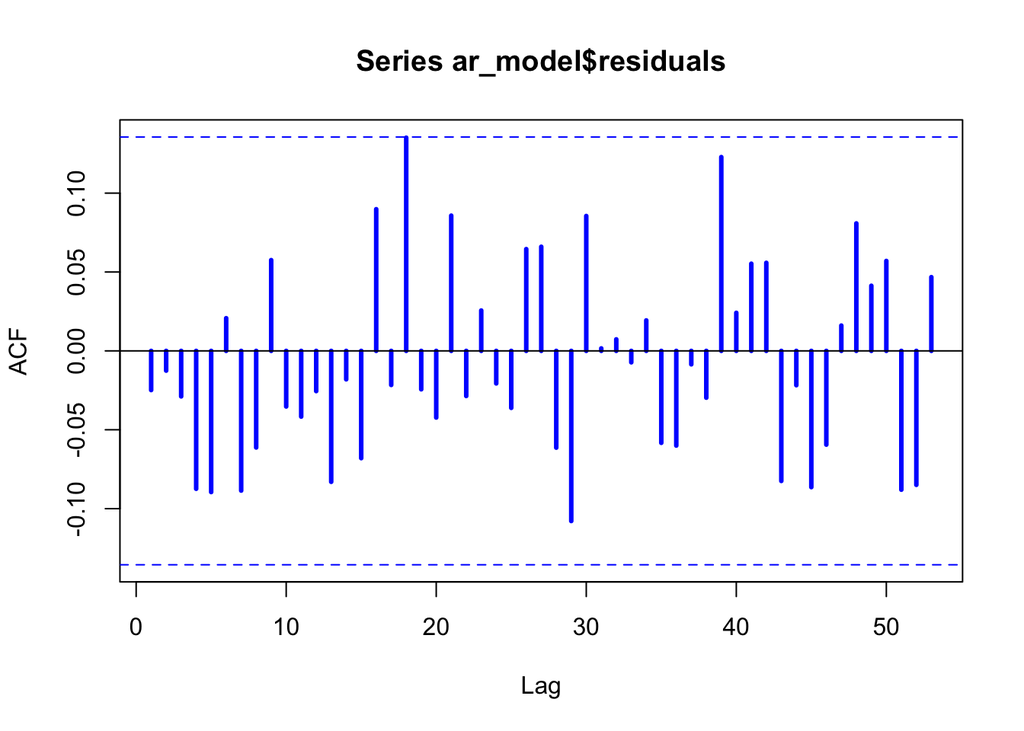

```r
acf(ar_model$residuals, lwd = 3, lag.max = 53, col = "blue")
```

Гипотеза о некоррелированности остатков не отвергается согласно тесту Бокса-Льюнга. На графиках коррелированность также не видна.

Для сравнения моделей воспользуемся информационным критерием Акаике.

```r
print(ar_model$aic)
```

```
## [1] 998.4563
```

```r
print(ma_model$aic)
```

```
## [1] 991.1562
```

Согласно нему модель с сезонным скользящим средним первого порядка и несезонным скользящим средним первого порядка лучше.

### Построение прогнозов

Построим прогноз на 12 недель с помощью выбранной модели с уровнем 0.95.

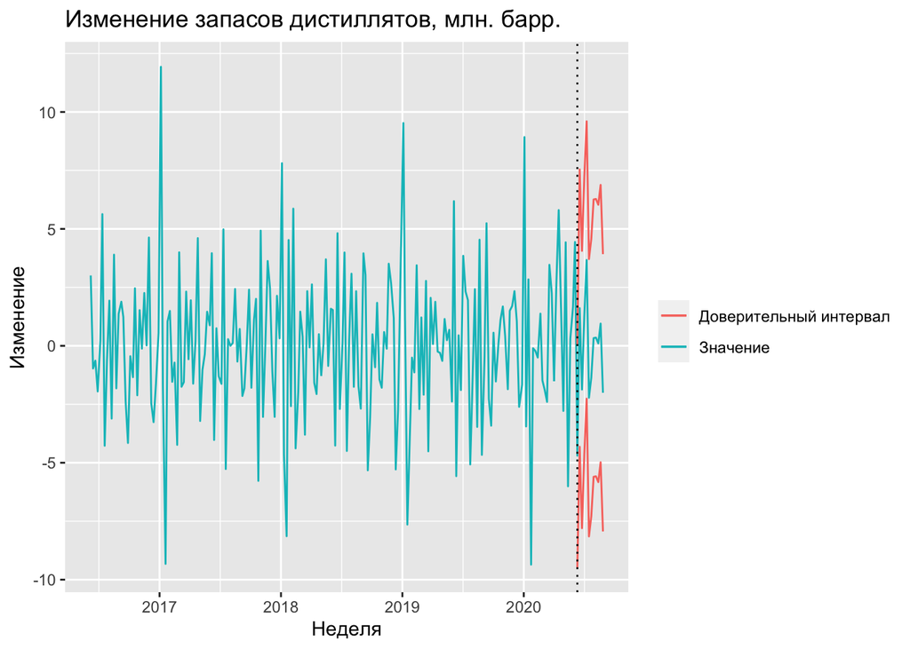

```r
fc <- predict(ma_model, n.ahead = 12)
fc_bottom <- fc$pred - 2 * fc$se
fc_up <- fc$pred + 2 * fc$se

forecast <- tibble(
  Date = seq(from=as.Date("2020/06/10"), by="week", length.out = length(fc$pred)),
  Diff = fc$pred,
  Bottom = fc_bottom,
  Up = fc_up
)

merged <- bind_rows(diff %>% select(Date, Diff, Inc), forecast) %>%
  arrange(Date) %>%
  mutate(Restored = Diff + lag(Inc, n = 52),
    Inc_Bottom = Bottom + lag(Inc, n = 52),
    Inc_Up = Up + lag(Inc, n = 52)) %>%
  mutate(Inc = coalesce(Inc, Restored)) %>%
  select(-Restored)

ggplot(merged) +
  geom_line(aes(x=Date, y = Inc, color="Значение")) +
  geom_line(aes(x=Date, y = Inc_Bottom, color="Доверительный интервал")) +
  geom_line(aes(x=Date, y = Inc_Up, color="Доверительный интервал")) +
  geom_vline(xintercept = as.Date("2020/06/10"), linetype="dotted") +
  labs(title='Изменение запасов дистиллятов, млн. барр.', x='Неделя', y='Изменение', color='')
```

Построим прогноз на 12 недель сезонным методом Хольта-Уинтерса.

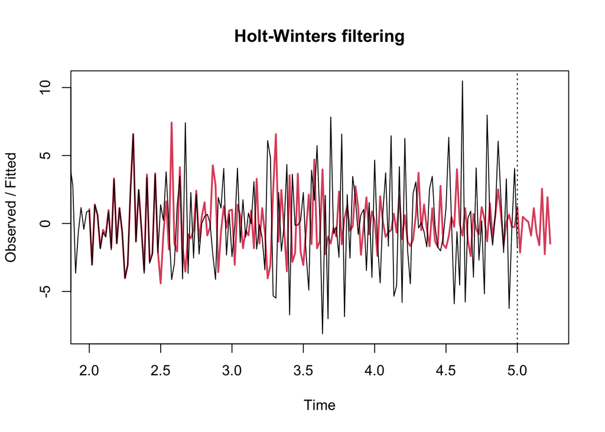

```r
model <- HoltWinters(ts(diff$Diff, frequency = 52), seasonal = "additive")
pred <- predict(model,n.ahead = 12)
plot(model, predicted.values = pred, lwd=2)
```